# Exercise Prediction

Satakarni Bommuluri

### Abstract

The human workout activity is captured using devices such as such as *Jawbone Up, Nike FuelBand, and Fitbit*. Often times this data is used to quantify the workout and not so much to determine the quality of the workout. In this paper, set of prediction models are used to determine how well they do the workout. For this purpose, I use data from accelerometers on the belt, forearm, arm, and dumbbell of 6 participants. They were asked to perform barbell lifts correctly and incorrectly in 5 different ways. More information about data is available from the [website here](http://groupware.les.inf.puc-rio.br/har) (see the section on the Weight Lifting Exercise Dataset). This paper ranks the quality of work based on following classes:

1. exactly according to the specification (Class A)
2. throwing the elbows to the front (Class B)
3. lifting the dumbbell only halfway (Class C)
4. lowering the dumbbell only halfway (Class D)
5. throwing the hips to the front (Class E)

### Data

Download the data

```r
if(!file.exists("pml-training.csv")){
  download.file(url = "https://d396qusza40orc.cloudfront.net/predmachlearn/pml-training.csv", destfile = "pml-training.csv")
}
if(!file.exists("pml-testing.csv")){
 download.file(url = "https://d396qusza40orc.cloudfront.net/predmachlearn/pml-testing.csv", destfile = "pml-testing.csv")
}
```

Read data into dataframes

```r
training <- read.csv(file = "pml-training.csv",  na.strings = c("NA", "#DIV/0!", ""))
validation <- read.csv(file = "pml-testing.csv", na.strings = c("NA", "#DIV/0!", ""))
```

Dealing with missing values

```r
#remove the columns with all missing values
training <- training[,colSums(is.na(training))==0]
validation <- validation[,colSums(is.na(validation))==0]
```

Removing the features not necessary for predicting the class of exercise

```r
suppressMessages(library(dplyr))
training <- select(training, -X, -user_name, -raw_timestamp_part_1, -raw_timestamp_part_2, -new_window, -num_window)
validation <- select(validation, -X, -user_name, -raw_timestamp_part_1, -raw_timestamp_part_2, -new_window, -num_window)
```

Partition training Data into NewTraining (75%) and NewTesting (25%)

```r
suppressMessages(library(caret))
set.seed(12345)
inTrain <- createDataPartition(y = training$classe, p = (3/4), list = FALSE)
NewTraining <- training[inTrain,]
NewTesting <- training[-inTrain,]
#trainingData <- createDataPartition(y)
```

Explore the (outcome) Class field of New Training Data

```r
dim(NewTraining)
```

```
## [1] 14718    54
```

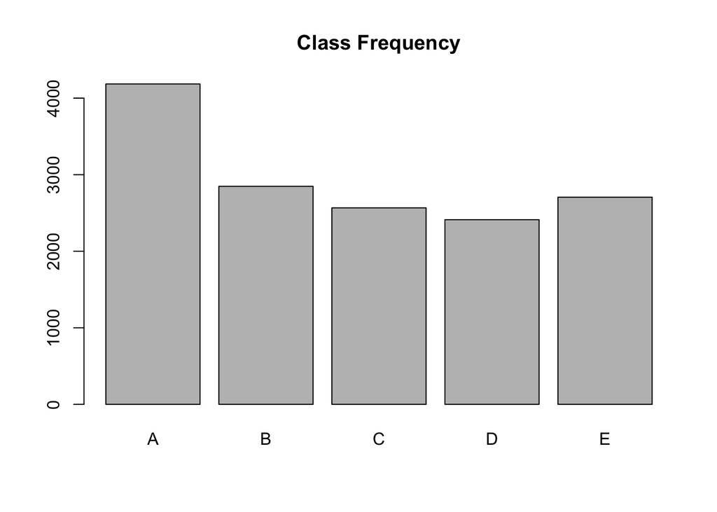

```r
plot(NewTraining$classe, main = "Class Frequency")
```

### Modelling 01: Decision Tree

We begin our modelling with simple decision tree.

```r
suppressMessages(library(rpart)); suppressMessages((library(rpart.plot)))
```

```
##  [1] "rpart.plot" "rpart"      "caret"      "ggplot2"    "lattice"
##  [6] "dplyr"      "stats"      "graphics"   "grDevices"  "utils"
## [11] "datasets"   "methods"    "base"
```

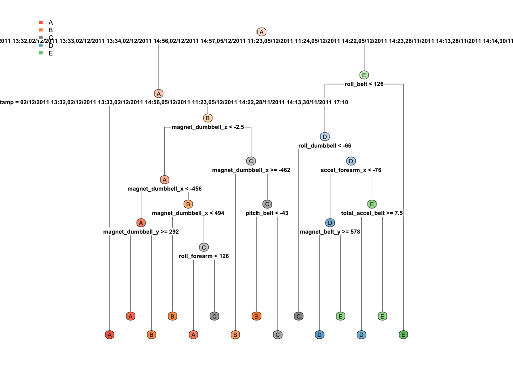

```r
model01 <- rpart(formula = (classe~.), data = NewTraining, method = "class") #method is class as the variable classe is a level
rpart.plot(x = model01, extra=0)
```

Testing the model01 prediciton

```r
predict01 <- predict(object = model01, newdata = NewTesting, type = "class")
confusionMatrix(predict01, NewTesting$classe)
```

```
## Confusion Matrix and Statistics
##
##           Reference
## Prediction    A    B    C    D    E
##          A 1352  185    0    0    0
##          B   22  625   76   42    0
##          C   21  136  763  113   44
##          D    0    3   10  558   63
##          E    0    0    6   91  794
##
## Overall Statistics
##
##                Accuracy : 0.8344
##                  95% CI : (0.8237, 0.8447)
##     No Information Rate : 0.2845
##     P-Value [Acc > NIR] : < 2.2e-16
##
##                   Kappa : 0.7898
##  Mcnemar's Test P-Value : NA
##
## Statistics by Class:
##
##                      Class: A Class: B Class: C Class: D Class: E
## Sensitivity            0.9692   0.6586   0.8924   0.6940   0.8812
## Specificity            0.9473   0.9646   0.9224   0.9815   0.9758
## Pos Pred Value         0.8796   0.8170   0.7084   0.8801   0.8911
## Neg Pred Value         0.9872   0.9217   0.9760   0.9424   0.9733
## Prevalence             0.2845   0.1935   0.1743   0.1639   0.1837
## Detection Rate         0.2757   0.1274   0.1556   0.1138   0.1619
## Detection Prevalence   0.3134   0.1560   0.2196   0.1293   0.1817
## Balanced Accuracy      0.9582   0.8116   0.9074   0.8377   0.9285
```

### Modelling 02: Random Forest

We now continue building the “mighty” random forest.

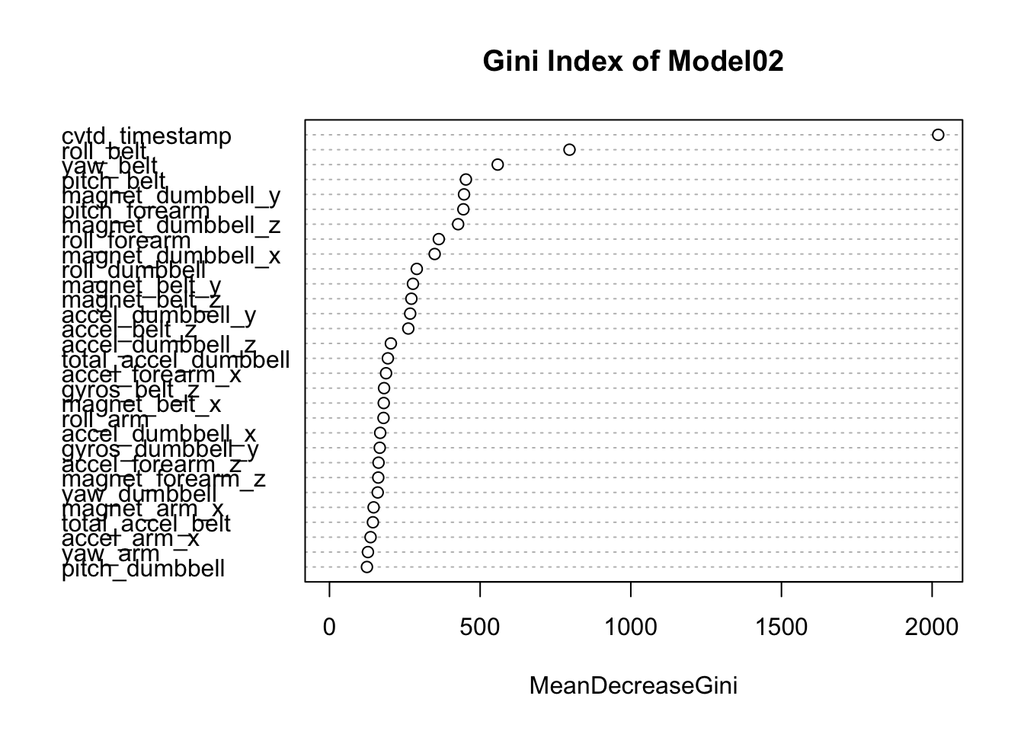

```r
suppressMessages(library(randomForest))
set.seed(12345)
model02 <- randomForest(classe ~ ., data = NewTraining, method = "class")
#treePLot <- getTree(rfobj = model02, k = 1, labelVar = TRUE)
varImpPlot(model02, main = "Gini Index of Model02")
```

Tetsing the model02 prediciton

```r
predict02 <- predict(object = model02, newdata = NewTesting)
confusionMatrix(predict02, NewTesting$classe)
```

```
## Confusion Matrix and Statistics
##
##           Reference
## Prediction    A    B    C    D    E
##          A 1392    7    0    0    0
##          B    3  938    2    0    0
##          C    0    4  850    4    0
##          D    0    0    3  800    4
##          E    0    0    0    0  897
##
## Overall Statistics
##
##                Accuracy : 0.9945
##                  95% CI : (0.992, 0.9964)
##     No Information Rate : 0.2845
##     P-Value [Acc > NIR] : < 2.2e-16
##
##                   Kappa : 0.993
##  Mcnemar's Test P-Value : NA
##
## Statistics by Class:
##
##                      Class: A Class: B Class: C Class: D Class: E
## Sensitivity            0.9978   0.9884   0.9942   0.9950   0.9956
## Specificity            0.9980   0.9987   0.9980   0.9983   1.0000
## Pos Pred Value         0.9950   0.9947   0.9907   0.9913   1.0000
## Neg Pred Value         0.9991   0.9972   0.9988   0.9990   0.9990
## Prevalence             0.2845   0.1935   0.1743   0.1639   0.1837
## Detection Rate         0.2838   0.1913   0.1733   0.1631   0.1829
## Detection Prevalence   0.2853   0.1923   0.1750   0.1646   0.1829
## Balanced Accuracy      0.9979   0.9936   0.9961   0.9967   0.9978
```

### Cross Validation

```r
colnames(validation) = colnames(training)
#All predictors need be at same level as training levels for randomForest() function
levels(validation$cvtd_timestamp) <- levels(NewTraining$cvtd_timestamp)
predict03 <- predict(object = model02, newdata = validation, type = "class")
```

### Submission of 20 test cases results

```r
predict03
```

```
##  1  2  3  4  5  6  7  8  9 10 11 12 13 14 15 16 17 18 19 20
##  B  A  B  A  A  E  D  B  A  A  B  C  B  A  E  E  A  B  B  B
## Levels: A B C D E
```